# Sampling distributions

# 6 Putting it all together: sampling distributions, standard errors and probabilities

Imagine we repeatedly draw lots of 200-observation samples from the telco population. Given what we now know about sampling mean(monthly_charges), what proportion `same as probailaty` of these samples will have a mean(monthly_charges) in the range from 60 to 70 Euros?

```r
library(fastGraph)
```

standard errors for the three sampling distributions

```r
std_errs <- rep_sample_200 %>%
  summarise(se_mean_monthly = sd(mean_monthly_charges),
            se_mean_tenure = sd(mean_tenure),
            se_prop_churn = sd(prop_churn)
            )

std_errs
```

| se_mean_monthly | se_mean_tenure | se_prop_churn |
| --- | --- | --- |
| 2.089817 | 1.701673 | 0.03049908 |

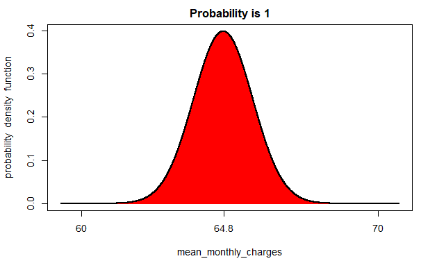

```r
# we need the mean(mean_monthly_charges) to center the curve
# and the sample_size = 200 standard error in the mean to give the curve width
# shadeDist can shade regions on a prob dist and report probability
# parm1 is mean
# parm2 is sd
shadeDist(
  xshade = c(60, 70),
  lower.tail = FALSE,
  ddist = "dnorm",
  parm1 = mean(rep_sample_200$mean_monthly_charges),
  parm2 = std_errs$se_mean_monthly_charges,
  xlab = "mean_monthly_charges"
)
```

```r
rep_sample_200 %>%
  filter(mean_monthly_charges >= 60,
         mean_monthly_charges <= 70) %>%
  summarise(prop = n()/ nrow(rep_sample_200))
```

| prop |
| --- |
| 0.9824 |

So the probabilities (proportions) calculated both ways are very similar! But which of these methods is better? **The second is preferable**, as it doesn’t make any assumption that the sampling distribution is normal. We’ll use resampling methods like this throughout the rest of the week.

### Task - 10 mins

Try creating either a shaded normal plot or use the filtering method to answer this question:

What proportion of 200-observation samples of tenure will have a mean(tenure) in the range 30 to 35 months?

```r
rep_sample_200 %>%
  filter(mean_tenure >= 30,
         mean_tenure <= 35) %>%
  summarise(prop = n()/ nrow(rep_sample_200))
```

| prop |
| --- |
| 0.8606 |

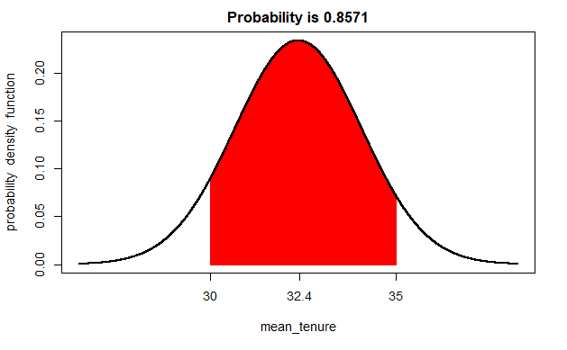

```r
shadeDist(
  xshade = c(30, 35),
  lower.tail = FALSE,
  ddist = "dnorm",
  parm1 = mean(rep_sample_200$mean_tenure),
  parm2 = std_errs$se_mean_tenure,
  xlab = "mean_tenure"
)
```